# ProsperLoan Data Exploration

## by Pride Ngonidzashe Guwhe

## Introduction

This document explores a dataset called Loan Data from Prosper that was last updated on 03/11/2014 containing 113,937 loans. The dataset has 81 variables on each loan, including loan amount, borrower rate (or interest rate), current loan status, borrower income, and many others. The dataset is not clean as it is observed with some variables in the dataset having null values for example CreditGrade, ClosedDate just mention a few.

According to Investopedia "Financial institutions attempt to mitigate the risk of lending to borrowers by performing a credit analysis on individuals and businesses applying for a new credit account or loan. This process is based on a review of five key factors that predict the probability of a borrower defaulting on his debt. Called the five Cs of credit, they include capacity, capital, conditions, character, and collateral. There is no regulatory standard that requires the use of the five Cs of credit, but the majority of lenders review most of this information prior to allowing a borrower to take on debt.

Lenders measure each of the five Cs of credit differently some qualitative vs. quantitative, for example—as they do not always lend themselves easily to a numerical calculation. Although each financial institution employs its own variation of the process to determine creditworthiness, most lenders place the greatest amount of weight on a borrower's capacity.

#### Capacity

Lenders must be sure that the borrower has the ability to repay the loan based on the proposed amount and terms. For business-loan applications, the financial institution reviews the company's past cash flow statements to determine how much income is expected from operations. Individual borrowers provide detailed information about the income they earn as well as the stability of their employment. Capacity is also determined by analyzing the number and amount of debt obligations the borrower currently has outstanding, compared to the amount of income or revenue expected each month.

Most lenders have specific formulas they use to determine whether a borrower's capacity is acceptable. Mortgage companies, for example, use the debt-to-income ratio, which states a borrower's monthly debt as a percentage of his monthly income. A high debt to income ratio is perceived by lenders as high risk, and it may lead to a decline or altered terms of repayment that cost more over the duration of the loan or credit line.

#### Capital

Lenders also analyze a borrower's capital level when determining creditworthiness. Capital for a business-loan application consists of personal investment into the firm, retained earnings, and other assets controlled by the business owner. For personal-loan applications, capital consists of savings or investment account balances. Lenders view capital as an additional means to repay the debt obligation should income or revenue be interrupted while the loan is still in repayment.

Banks prefer a borrower with a lot of capital because that means the borrower has some skin in the game. If the borrower's own money is involved, it gives them a sense of ownership and provides an added incentive not to default on the loan. Banks measure capital quantitatively as a percentage of the total investment cost.

#### Conditions

Conditions refer to the terms of the loan itself, as well as any economic conditions that might affect the borrower. Business lenders review conditions such as the strength or weakness of the overall economy and the purpose of the loan. Financing for working capital, equipment, or expansion are common reasons listed on business loan applications. While this criterion tends to apply more to corporate applicants, individual borrowers are also analyzed for their need for taking on the debt. Common reasons include home renovations, debt consolidation, or financing major purchases.

This factor is the most subjective of the five Cs of credit and is evaluated mostly qualitatively. However, lenders also use certain quantitative measurements such as the loan's interest rate, principal amount, and repayment length to assess conditions.

#### Character

Character refers to a borrower's reputation or record vis-à-vis financial matters. The old adage that past behavior is the best predictor of future behavior is one that lenders devoutly subscribe to. Each has its own formula or approach for determining a borrower's character, honesty, and reliability, but this assessment typically includes both qualitative and quantitative methods.

The more subjective ones include analyzing the debtor's educational background and employment history; calling personal or business references; and conducting a personal interview with the borrower. More objective methods include reviewing the applicant's credit history or score, which credit reporting agencies standardize to a common scale.

Although each of these factors plays a role in determining the borrower's character, lenders place more weight on the last two. If a borrower has not managed past debt repayment well or has a previous bankruptcy, their character is deemed less acceptable than a borrower with a clean credit history.

#### Collateral

Personal assets pledged by a borrower as security for a loan are known as collateral. Business borrowers may use equipment or accounts receivable to secure a loan, while individual debtors often pledge savings, a vehicle, or a home as collateral. Applications for a secured loan are looked upon more favorably than those for an unsecured loan because the lender can collect the asset should the borrower stop making loan payments. Banks measure collateral quantitatively by its value and qualitatively by its perceived ease of liquidation."

## Preliminary Wrangling

```python
# import all packages and set plots to be embedded inline
import numpy as np
import pandas as pd
import matplotlib.pyplot as plt
import seaborn as sb

%matplotlib inline
```

```python
# load in the dataset into a pandas dataframe
loan_data= pd.read_csv('prosperLoanData.csv')
```

```python
# high-level overview of data shape and composition
print(loan_data.shape)
```

```
(113937, 81)
```

```python
loan_data.info()
```

```
<class 'pandas.core.frame.DataFrame'>
RangeIndex: 113937 entries, 0 to 113936
Data columns (total 81 columns):
 #   Column                               Non-Null Count   Dtype
---  ------                               --------------   -----
 0   ListingKey                           113937 non-null  object
 1   ListingNumber                        113937 non-null  int64
 2   ListingCreationDate                  113937 non-null  object
 3   CreditGrade                          28953 non-null   object
 4   Term                                 113937 non-null  int64
 5   LoanStatus                           113937 non-null  object
 6   ClosedDate                           55089 non-null   object
 7   BorrowerAPR                          113912 non-null  float64
 8   BorrowerRate                         113937 non-null  float64
 9   LenderYield                          113937 non-null  float64
```

[output cut: 73 more lines]

```python
# retaining columns that are significant to the research questions
loan_data = loan_data.loc[:, ["Term", "LoanStatus", "BorrowerAPR", "BorrowerRate", "LenderYield", "DebtToIncomeRatio", "ListingCategory (numeric)", "Occupation", "EmploymentStatus", "EmploymentStatusDuration", "IsBorrowerHomeowner", "CreditScoreRangeLower", "CreditScoreRangeUpper", "IncomeVerifiable", "StatedMonthlyIncome", "LoanOriginalAmount"]]
loan_data.head()
```

|  | Term | LoanStatus | BorrowerAPR | BorrowerRate | LenderYield | DebtToIncomeRatio | ListingCategory (numeric) | Occupation | EmploymentStatus | EmploymentStatusDuration | IsBorrowerHomeowner | CreditScoreRangeLower | CreditScoreRangeUpper | IncomeVerifiable | StatedMonthlyIncome | LoanOriginalAmount |
| --- | --- | --- | --- | --- | --- | --- | --- | --- | --- | --- | --- | --- | --- | --- | --- | --- |
| 0 | 36 | Completed | 0.16516 | 0.1580 | 0.1380 | 0.17 | 0 | Other | Self-employed | 2.0 | True | 640.0 | 659.0 | True | 3083.333333 | 9425 |
| 1 | 36 | Current | 0.12016 | 0.0920 | 0.0820 | 0.18 | 2 | Professional | Employed | 44.0 | False | 680.0 | 699.0 | True | 6125.000000 | 10000 |
| 2 | 36 | Completed | 0.28269 | 0.2750 | 0.2400 | 0.06 | 0 | Other | Not available | NaN | False | 480.0 | 499.0 | True | 2083.333333 | 3001 |
| 3 | 36 | Current | 0.12528 | 0.0974 | 0.0874 | 0.15 | 16 | Skilled Labor | Employed | 113.0 | True | 800.0 | 819.0 | True | 2875.000000 | 10000 |
| 4 | 36 | Current | 0.24614 | 0.2085 | 0.1985 | 0.26 | 2 | Executive | Employed | 44.0 | True | 680.0 | 699.0 | True | 9583.333333 | 15000 |

```python
# checking for missing values
loan_data.info()
```

```
<class 'pandas.core.frame.DataFrame'>
RangeIndex: 113937 entries, 0 to 113936
Data columns (total 16 columns):
 #   Column                     Non-Null Count   Dtype
---  ------                     --------------   -----
 0   Term                       113937 non-null  int64
 1   LoanStatus                 113937 non-null  object
 2   BorrowerAPR                113912 non-null  float64
 3   BorrowerRate               113937 non-null  float64
 4   LenderYield                113937 non-null  float64
 5   DebtToIncomeRatio          105383 non-null  float64
 6   ListingCategory (numeric)  113937 non-null  int64
 7   Occupation                 110349 non-null  object
 8   EmploymentStatus           111682 non-null  object
 9   EmploymentStatusDuration   106312 non-null  float64
 10  IsBorrowerHomeowner        113937 non-null  bool
 11  CreditScoreRangeLower      113346 non-null  float64
 12  CreditScoreRangeUpper      113346 non-null  float64
 13  IncomeVerifiable           113937 non-null  bool
 14  StatedMonthlyIncome        113937 non-null  float64
 15  LoanOriginalAmount         113937 non-null  int64
dtypes: bool(2), float64(8), int64(3), object(3)
memory usage: 12.4+ MB
```

```python
# dropping missing values
loan_data.dropna(inplace=True)
```

```python
# adding a new column
loan_data['AverageCreditScore'] = loan_data.apply(lambda row: (row.CreditScoreRangeLower + row.CreditScoreRangeUpper)/2, axis = 1)
loan_data.head()
```

|  | Term | LoanStatus | BorrowerAPR | BorrowerRate | LenderYield | DebtToIncomeRatio | ListingCategory (numeric) | Occupation | EmploymentStatus | EmploymentStatusDuration | IsBorrowerHomeowner | CreditScoreRangeLower | CreditScoreRangeUpper | IncomeVerifiable | StatedMonthlyIncome | LoanOriginalAmount | AverageCreditScore |
| --- | --- | --- | --- | --- | --- | --- | --- | --- | --- | --- | --- | --- | --- | --- | --- | --- | --- |
| 0 | 36 | Completed | 0.16516 | 0.1580 | 0.1380 | 0.17 | 0 | Other | Self-employed | 2.0 | True | 640.0 | 659.0 | True | 3083.333333 | 9425 | 649.5 |
| 1 | 36 | Current | 0.12016 | 0.0920 | 0.0820 | 0.18 | 2 | Professional | Employed | 44.0 | False | 680.0 | 699.0 | True | 6125.000000 | 10000 | 689.5 |
| 3 | 36 | Current | 0.12528 | 0.0974 | 0.0874 | 0.15 | 16 | Skilled Labor | Employed | 113.0 | True | 800.0 | 819.0 | True | 2875.000000 | 10000 | 809.5 |
| 4 | 36 | Current | 0.24614 | 0.2085 | 0.1985 | 0.26 | 2 | Executive | Employed | 44.0 | True | 680.0 | 699.0 | True | 9583.333333 | 15000 | 689.5 |
| 5 | 60 | Current | 0.15425 | 0.1314 | 0.1214 | 0.36 | 1 | Professional | Employed | 82.0 | True | 740.0 | 759.0 | True | 8333.333333 | 15000 | 749.5 |

```python
# changing the ListingCategory from numeric to categorical
list_cat={0:'Not Available',1:'Debt Consolidation',2:'Home Improvement',3:'Business',4:'Personal Loan',5:'Student Use',6:'Auto',
 7:'Other',8:'Baby&Adoption',9:'Boat',10:'Cosmetic Procedure',11:'Engagement Ring',12:'Green Loans',
 13:'Household Expenses',14:'Large Purchases',15:'Medical/Dental',16:'Motorcycle',17:'RV',18:'Taxes',19:'Vacation',20:'Wedding Loans'}
```

```python
# running a loop over dataset and dictionary created.
# appending dictionary values to a list based on keys which are equal to the values present in our listing category.
l=[]
for i in range(loan_data.shape[0]):
    for j in range(len(list_cat)):
        if loan_data['ListingCategory (numeric)'].values[i] == list(list_cat.keys())[j]:
            l.append(list(list_cat.values())[j])
```

```python
# assigning a new column with listing labels.
loan_data['ListingConditions'] = l
```

```python
# dropping columns
loan_data.drop(labels=['ListingCategory (numeric)', 'CreditScoreRangeLower', 'CreditScoreRangeUpper'], axis=1, inplace=True)
```

```python
loan_data.head()
```

|  | Term | LoanStatus | BorrowerAPR | BorrowerRate | LenderYield | DebtToIncomeRatio | Occupation | EmploymentStatus | EmploymentStatusDuration | IsBorrowerHomeowner | IncomeVerifiable | StatedMonthlyIncome | LoanOriginalAmount | AverageCreditScore | ListingConditions |
| --- | --- | --- | --- | --- | --- | --- | --- | --- | --- | --- | --- | --- | --- | --- | --- |
| 0 | 36 | Completed | 0.16516 | 0.1580 | 0.1380 | 0.17 | Other | Self-employed | 2.0 | True | True | 3083.333333 | 9425 | 649.5 | Not Available |
| 1 | 36 | Current | 0.12016 | 0.0920 | 0.0820 | 0.18 | Professional | Employed | 44.0 | False | True | 6125.000000 | 10000 | 689.5 | Home Improvement |
| 3 | 36 | Current | 0.12528 | 0.0974 | 0.0874 | 0.15 | Skilled Labor | Employed | 113.0 | True | True | 2875.000000 | 10000 | 809.5 | Motorcycle |
| 4 | 36 | Current | 0.24614 | 0.2085 | 0.1985 | 0.26 | Executive | Employed | 44.0 | True | True | 9583.333333 | 15000 | 689.5 | Home Improvement |
| 5 | 60 | Current | 0.15425 | 0.1314 | 0.1214 | 0.36 | Professional | Employed | 82.0 | True | True | 8333.333333 | 15000 | 749.5 | Debt Consolidation |

```python
# checking for missing data one last time
loan_data.info()
```

```
<class 'pandas.core.frame.DataFrame'>
Int64Index: 96561 entries, 0 to 113936
Data columns (total 15 columns):
 #   Column                    Non-Null Count  Dtype
---  ------                    --------------  -----
 0   Term                      96561 non-null  int64
 1   LoanStatus                96561 non-null  object
 2   BorrowerAPR               96561 non-null  float64
 3   BorrowerRate              96561 non-null  float64
 4   LenderYield               96561 non-null  float64
 5   DebtToIncomeRatio         96561 non-null  float64
 6   Occupation                96561 non-null  object
 7   EmploymentStatus          96561 non-null  object
 8   EmploymentStatusDuration  96561 non-null  float64
 9   IsBorrowerHomeowner       96561 non-null  bool
 10  IncomeVerifiable          96561 non-null  bool
 11  StatedMonthlyIncome       96561 non-null  float64
 12  LoanOriginalAmount        96561 non-null  int64
 13  AverageCreditScore        96561 non-null  float64
 14  ListingConditions         96561 non-null  object
dtypes: bool(2), float64(7), int64(2), object(4)
memory usage: 10.5+ MB
```

```python
# checking for duplicated rows
sum(loan_data.duplicated())
```

```
730
```

```python
loan_data.drop_duplicates(inplace=True)
```

```python
# checking for duplicated rows one last time
sum(loan_data.duplicated())
```

```
0
```

### What is/are the main feature(s) of interest in your dataset?

> I'm most interested in figuring out what features are significant when conducting credit analysis in the dataset by answering the following questions :
> 1. What factors affect a loan’s outcome status?
> 2. What affects the borrower’s APR or interest rate?
> 3. Are there differences between loans depending on how large the original loan amount was?

### What features in the dataset do you think will help support your investigation into your feature(s) of interest?

I expect that the majority of the features either numeric or categorical to have a significant effect on the loan outcome status. I also think that LenderYield has a significant effect on either borrower's APR or interest rate compared to other features. I also expect that differences between loans is not only as a result of how large the original loan amount was.

## Univariate Exploration

### Let's look at our first variable "Term".

> **Rubric Tip**: Visualizations should depict the data appropriately so that the plots are easily interpretable. You should choose an appropriate plot type, data encodings, and formatting as needed. The formatting may include setting/adding the title, labels, legend, and comments. Also, do not overplot or incorrectly plot ordinal data.

```python
loan_data.Term.value_counts()
```

```
36    71813
60    22603
12     1415
Name: Term, dtype: int64
```

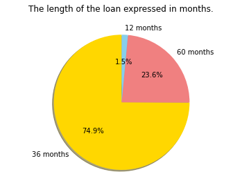

```python
# pie-chart
labels = '36 months', '60 months', '12 months'
sizes = [71813, 22603, 1415]
colors = ['gold', 'lightcoral', 'skyblue']
explode = (0, 0, 0)

plt.pie(sizes, explode = explode, labels = labels, colors = colors, autopct = '%1.1f%%', shadow = True, startangle = 90)

plt.axis('equal')
plt.title('The length of the loan expressed in months.', y = 1.08);
```

### Let's look at our second variable "LoanStatus".

```python
loan_Status = loan_data.LoanStatus.value_counts()
loan_Status
```

```
Current                   50462
Completed                 30851
Chargedoff                 9422
Defaulted                  3075
Past Due (1-15 days)        709
Past Due (31-60 days)       320
Past Due (91-120 days)      277
Past Due (61-90 days)       274
Past Due (16-30 days)       241
FinalPaymentInProgress      185
Past Due (>120 days)         14
Cancelled                     1
Name: LoanStatus, dtype: int64
```

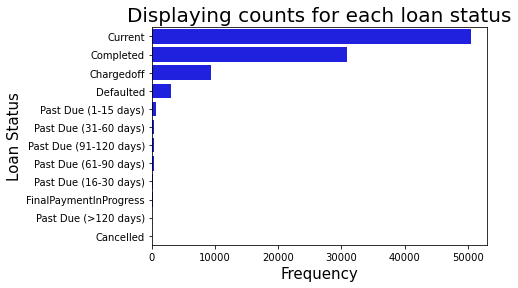

```python
# Barplot
sb.countplot(y='LoanStatus',data = loan_data,color='blue', order = loan_Status.index)
plt.ylabel('Loan Status', fontsize = 15)
plt.xlabel('Frequency', fontsize = 15)
plt.title('Displaying counts for each loan status', fontsize = 20);
```

> We can observe that the loan status with the highest frequency is current, followed by completed, chargedoff, defaulted and so on. We will find out why this is so since for now we are observing the distribution of the variable.

### Let's look at our third variable "BorrowerAPR".

```python
loan_data['BorrowerAPR'].describe()
```

```
count    95831.000000
mean         0.217759
std          0.080376
min          0.006530
25%          0.154620
50%          0.207350
75%          0.280780
max          0.423950
Name: BorrowerAPR, dtype: float64
```

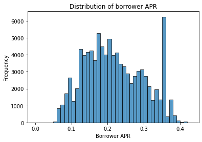

```python
# plotting histogram.
bins = np.arange(0, loan_data['BorrowerAPR'].max()+0.01,0.01)
sb.histplot(x = 'BorrowerAPR', data = loan_data, bins = bins)
plt.xlabel('Borrower APR')
plt.ylabel('Frequency')
plt.title('Distribution of borrower APR');
```

> The pick frequency of borrower APR is just after 0.35. The maximum borrower APR is over 40% and minimum APR is approximately 1%. There are some high bins between 0.16 and 0.2. There is a fall in frequency of APR values after 0.2 but again APR increases from 0.26 to 0.3. Then data fall and again their is huge rise in the frequency of APR. The distribution tends to be slighly skewed to the right.

### Let's look at our fourth variable "BorrowerRate".

```python
loan_data['BorrowerRate'].describe()
```

```
count    95831.000000
mean         0.190973
std          0.074724
min          0.000000
25%          0.131400
50%          0.180000
75%          0.249700
max          0.360000
Name: BorrowerRate, dtype: float64
```

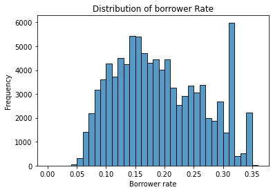

```python
# plotting histogram.
bins = np.arange(0, loan_data['BorrowerRate'].max()+0.01,0.01)
sb.histplot(x = 'BorrowerRate', data = loan_data, bins = bins)
plt.title('Distribution of borrower Rate')
plt.xlabel('Borrower rate')
plt.ylabel('Frequency');
```

> It is a bimodal distribution with one peak lie at round 0.15 and another peak lies between 0.30 and 0.33. It is right skewed distribution. After the 0.15 peak, the rate decrease in frequency but there is increase just before the highest pick of the rate.

### Let's look at our fifth variable "LenderYield"

```python
loan_data['LenderYield'].describe()
```

```
count    95831.000000
mean         0.180835
std          0.074470
min         -0.010000
25%          0.121400
50%          0.170000
75%          0.239200
max          0.340000
Name: LenderYield, dtype: float64
```

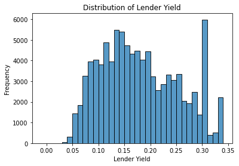

```python
# plotting histogram.
bins = np.arange(-0.01, loan_data['LenderYield'].max()+0.01,0.01)
sb.histplot(x = 'LenderYield', data = loan_data, bins = bins)
plt.title('Distribution of Lender Yield')
plt.xlabel('Lender Yield')
plt.ylabel('Frequency');
```

> The distribution is almost identical to the previous variable, although having a bimodal distribution where the bars increases in height before it reaches the first peak between lender yield of 0.1 and 0.15, then decrease until reaching 0.2. The bars then fluctuates in height before reaching another peak just after 0.30. It is also a right skewed distribution.

### Let's look at our sixth variable "DebtToIncomeRatio".

```python
loan_data['DebtToIncomeRatio'].describe()
```

```
count    95831.000000
mean         0.275816
std          0.529821
min          0.000000
25%          0.150000
50%          0.220000
75%          0.320000
max         10.010000
Name: DebtToIncomeRatio, dtype: float64
```

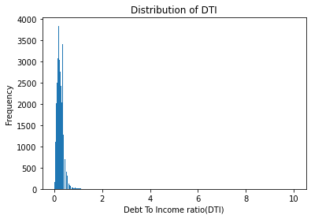

```python
# Plotting histogram
bins = np.arange(0, loan_data['DebtToIncomeRatio'].max()+0.01,0.01)
plt.hist(x='DebtToIncomeRatio',data=loan_data, bins = bins)
plt.title('Distribution of DTI')
plt.xlabel('Debt To Income ratio(DTI)')
plt.ylabel('Frequency');
```

> Using the normal scale, we observe that most of our data falls between 0 and 1. Also from our descriptive statistics we see that about 75% of our data is below 0.32. So values above one will be considered as outliers.

```python
# dropping outliers in debt to income ratio with ratio greater than 1.
loan_data = loan_data[loan_data['DebtToIncomeRatio']<1]
```

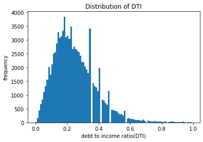

```python
# Plotting histogram
bins = np.arange(0, loan_data['DebtToIncomeRatio'].max()+0.01,0.01)
plt.hist(x='DebtToIncomeRatio',data=loan_data, bins = bins)
plt.title('Distribution of DTI')
plt.xlabel('debt to income ratio(DTI)')
plt.ylabel('frequency');
```

> We can see that the distribuion is skewed to the right, with the pick at around 0.2. Values after 0.6 can also be considered as outliers since the tail does not sharply dive before it reaches 1.

### Let's look at our sixth variable "Occupation".

```python
Occupation_order = loan_data.Occupation.value_counts()
Occupation_order
```

```
Other                          23315
Professional                   12230
Computer Programmer             3956
Executive                       3824
Teacher                         3434
                               ...
Homemaker                         32
Student - College Freshman        29
Judge                             22
Student - Community College       13
Student - Technical School         7
Name: Occupation, Length: 67, dtype: int64
```

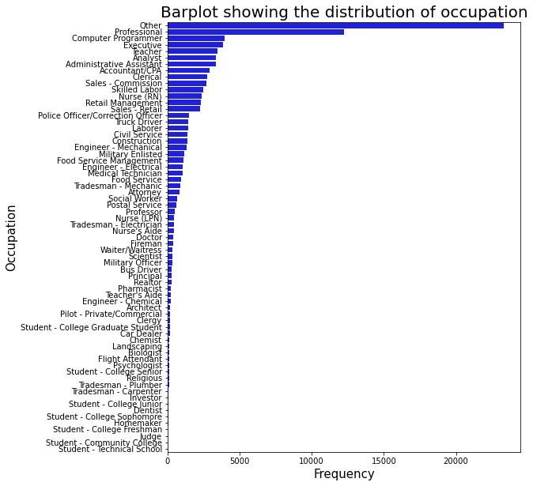

```python
# countplot
plt.figure(figsize=[8, 10])
sb.countplot(y='Occupation',data = loan_data,color='blue', order = Occupation_order.index)
plt.xlabel('Frequency', fontsize = 15)
plt.ylabel('Occupation', fontsize = 15)
plt.title('Barplot showing the distribution of occupation', fontsize = 20);
```

> Since this variable has many classes, it is difficult to get a clear picture from one chart, therefore the best way is to partition the classes according to the frequencies.

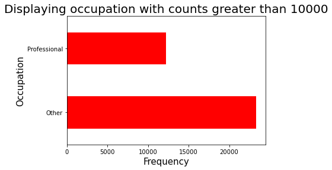

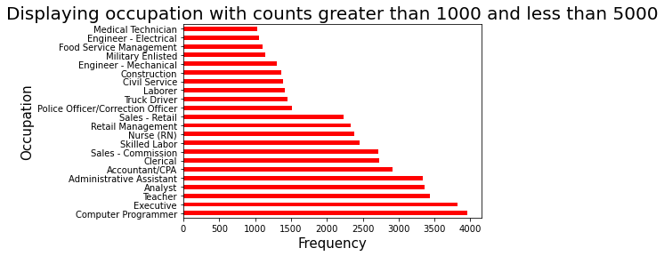

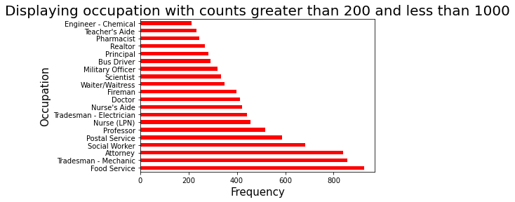

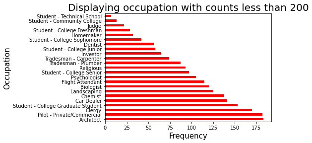

```python
occupations = loan_data['Occupation'].value_counts()

occupations[occupations >10000].plot.barh(color='red')
plt.title('Displaying occupation with counts greater than 10000', fontsize =20)
plt.xlabel('Frequency', fontsize = 15)
plt.ylabel('Occupation', fontsize = 15)
plt.show()


occupations[(occupations > 1000) & (occupations < 5000)].plot.barh(color='red')
plt.title('Displaying occupation with counts greater than 1000 and less than 5000',fontsize =20)
plt.xlabel('Frequency', fontsize = 15)
plt.ylabel('Occupation', fontsize = 15)
plt.show()

occupations[(occupations > 200) & (occupations < 1000)].plot.barh(color='red')
plt.title('Displaying occupation with counts greater than 200 and less than 1000',fontsize =20)
plt.xlabel('Frequency', fontsize = 15)
plt.ylabel('Occupation', fontsize = 15)
plt.show()

occupations[occupations < 200].plot.barh(color='red')
plt.title('Displaying occupation with counts less than 200', fontsize =20)
plt.xlabel('Frequency', fontsize = 15)
plt.ylabel('Occupation', fontsize = 15)
plt.show()
```

> I have partioned the original plot into 4 plots, with the first plot showing occupations with frequency of more than 10000. The second plot is a plot with frequency greater than 1000 but less than 5000. The third plot shows occupations with frequency greater than 200 but less than 1000. The last plot has occupations with frequency less than 200. From these plots we can clearly identify that the 'other' category has the highest frequency and student-technical school has the least frequency.

### Let's look at our seventh variable "EmploymentStatus ".

```python
Employment_Status = loan_data.EmploymentStatus.value_counts()
Employment_Status
```

```
Employed         64959
Full-time        25404
Other             2122
Self-employed      986
Part-time          899
Retired            713
Not employed        65
Name: EmploymentStatus, dtype: int64
```

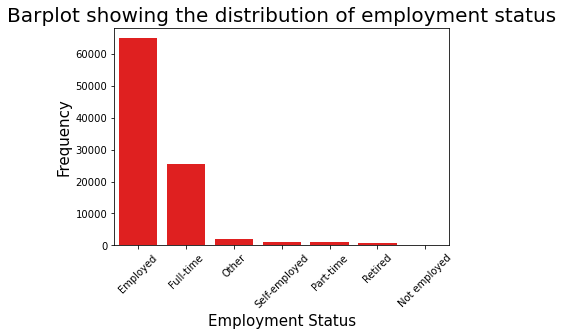

```python
# countplot
sb.countplot(x='EmploymentStatus',data = loan_data,color='red', order = Employment_Status.index)
plt.xticks(rotation=45)
plt.xlabel('Employment Status', fontsize = 15)
plt.ylabel('Frequency', fontsize = 15)
plt.title('Barplot showing the distribution of employment status', fontsize = 20);
```

> We can observe that borrowers with the highest frequency are employed and the borrowers with the least frequency are not employed.

### Let's look at the "EmploymentStatusDuration" variable.

```python
loan_data['EmploymentStatusDuration'].describe()
```

```
count    95148.000000
mean        97.212059
std         93.417693
min          0.000000
25%         27.000000
50%         69.000000
75%        139.000000
max        755.000000
Name: EmploymentStatusDuration, dtype: float64
```

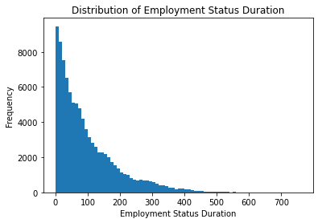

```python
# Plotting histogram
bins = np.arange(0, loan_data['EmploymentStatusDuration'].max()+10,10)
plt.hist(x='EmploymentStatusDuration',data=loan_data, bins = bins)
plt.title('Distribution of Employment Status Duration')
plt.xlabel('Employment Status Duration')
plt.ylabel('Frequency');
```

> The distribution show that our variable is skewed to the right. This is so because generally people move from job to job as people get promoted or can switch their employment status from being employed to not employed, retired or self-employed therefore that is why we see that the frequency decreases as the duration of employment status duration increases.

### Let's look at "IsBorrowerHomeowner" and "IncomeVerifiable" variables.

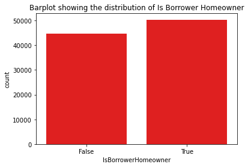

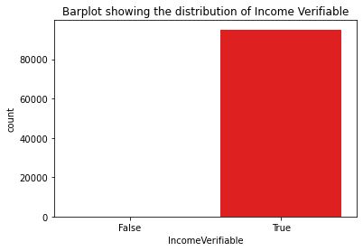

```python
sb.countplot(x='IsBorrowerHomeowner',data = loan_data,color='red')
plt.title('Barplot showing the distribution of Is Borrower Homeowner')
plt.show()

sb.countplot(x='IncomeVerifiable',data = loan_data,color='red')
plt.title('Barplot showing the distribution of Income Verifiable')
plt.show()
```

> From the barplot showing IsBorrowerHomeowner, True has higher count compared to False. This is could be the fact that banks prefer the home as the best collateral compared to other assets like cars because houses do not decrease in value due to depreciation. Also this could mean that our dataset has more individual loan applicants than business applicants.The second plot shows that banks are most likely to issue loans where the borrower has verifiable income than where the income is not verified.

### Let's look at the "StatedMonthlyIncome" variable.

```python
loan_data['StatedMonthlyIncome'].describe()
```

```
count     95148.000000
mean       5776.684419
std        4930.214437
min           0.000000
25%        3333.333333
50%        4916.666667
75%        7016.666667
max      483333.333333
Name: StatedMonthlyIncome, dtype: float64
```

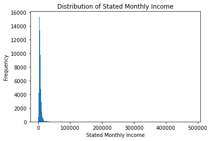

```python
# Plotting histogram
bins = np.arange(0, loan_data['StatedMonthlyIncome'].max()+1000,1000)
plt.hist(x='StatedMonthlyIncome',data=loan_data, bins = bins)
plt.title('Distribution of Stated Monthly Income')
plt.xlabel('Stated Monthly Income')
plt.ylabel('Frequency');
```

> We can see the distribution of stated monthly income is not clearly visible therefore there is need to transform the scale.

```python
np.log10(loan_data['StatedMonthlyIncome'].describe())
```

```
count    4.978400
mean     3.761679
std      3.692866
min          -inf
25%      3.522879
50%      3.691671
75%      3.846131
max      5.684247
Name: StatedMonthlyIncome, dtype: float64
```

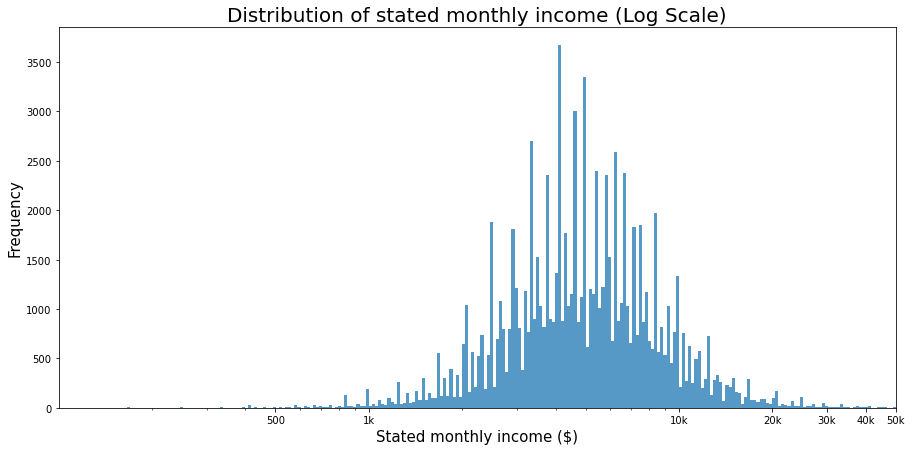

```python
# Plotting histogram
plt.figure(figsize=[15, 7])
bins = 10**np.arange(-1.07,5.6+0.1,0.01)
ax = sb.histplot(x='StatedMonthlyIncome',data=loan_data, bins = bins)
ax.set_xscale('log')
ax.set_xlim(100,50000)
ax.set_xlabel('Stated monthly income ($)',fontsize = 15)
ax.set_ylabel('Frequency',fontsize = 15)
ax.set_title('Distribution of stated monthly income (Log Scale)', fontsize = 20)
ax.set_xticks([500, 1000, 10000, 20000, 30000, 40000, 50000])
ax.set_xticklabels(['500', '1k', '10k', '20k', '30k', '40k', '50k']);
```

> Using the logarithmic scale on the x-axis, we can see that the distribution of stated monthly income is vastly spread between 1k(1000) and 20k(20000). The highest frequency has a stated monthly income of 4k(4000) on the log scale.

### Let's look at the "LoanOriginalAmount" variable.

```python
loan_data['LoanOriginalAmount'].describe()
```

```
count    95148.000000
mean      8700.437529
std       6364.864453
min       1000.000000
25%       4000.000000
50%       7000.000000
75%      12500.000000
max      35000.000000
Name: LoanOriginalAmount, dtype: float64
```

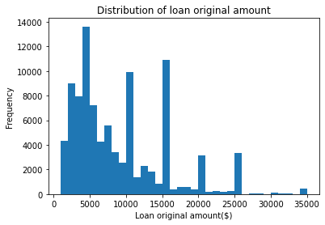

```python
# Plotting histogram.
bins = np.arange(1000,loan_data['LoanOriginalAmount'].max()+1000,1000)
plt.hist(x='LoanOriginalAmount',data=loan_data, bins = bins)
plt.title('Distribution of loan original amount')
plt.ylabel('Frequency')
plt.xlabel('Loan original amount($)');
```

> The distribution of the loan original amount is skewed to the right. From the descriptive statistics we can see that the minimum amount is 1000 and the maximum is 35000. The distribution is not clearly illustrated therefore transformations need to be applied.

```python
np.log10(loan_data['LoanOriginalAmount'].describe())
```

```
count    4.978400
mean     3.939541
std      3.803789
min      3.000000
25%      3.602060
50%      3.845098
75%      4.096910
max      4.544068
Name: LoanOriginalAmount, dtype: float64
```

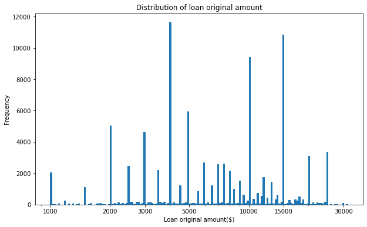

```python
# Plotting histogram.
plt.figure(figsize=[10,6])
bins = 10** np.arange(3,4.5+0.01,0.01)
tick = [1000,2000,3000,5000,10000,15000,30000]
labels=['{}'.format(x)for x in tick]
plt.hist(x='LoanOriginalAmount',data=loan_data, bins = bins)
plt.title('Distribution of loan original amount')
plt.xscale('log')
plt.xticks(tick,labels)
plt.ylabel('Frequency')
plt.xlabel('Loan original amount($)');
```

> We can see that the distribution is widely spread from 1000 to 30000 across the logarithmic scale. The distribution on a logarithmic scale is multimodal, with the highest peak between 3000 and 5000.

### Let's look at the "AverageCreditScore" variable.

```python
loan_data['AverageCreditScore'].describe()
```

```
count    95148.000000
mean       700.040211
std         57.051092
min        529.500000
25%        669.500000
50%        689.500000
75%        729.500000
max        889.500000
Name: AverageCreditScore, dtype: float64
```

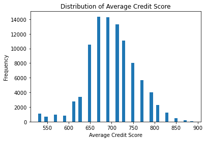

```python
# Plotting histogram.
plt.hist(x='AverageCreditScore',data=loan_data, bins = 50)
plt.title('Distribution of Average Credit Score')
plt.ylabel('Frequency')
plt.xlabel('Average Credit Score');
```

> We can observe that the distribution of Average Credit Score is almost similar to a bell shaped distribution with steeper sides. Few borrowers have the best credit score with the majority having a credit score that is moderate.

### Let's look at the "ListingConditions" variable.

```python
Conditions = loan_data.ListingConditions.value_counts()
Conditions
```

```
Debt Consolidation    52734
Other                  9344
Not Available          8879
Home Improvement       6844
Business               5149
Auto                   2333
Personal Loan          2252
Household Expenses     1747
Medical/Dental         1363
Large Purchases         781
Taxes                   778
Wedding Loans           718
Vacation                702
Student Use             593
Motorcycle              287
Engagement Ring         198
Baby&Adoption           188
Boat                     83
Cosmetic Procedure       82
RV                       49
Green Loans              44
Name: ListingConditions, dtype: int64
```

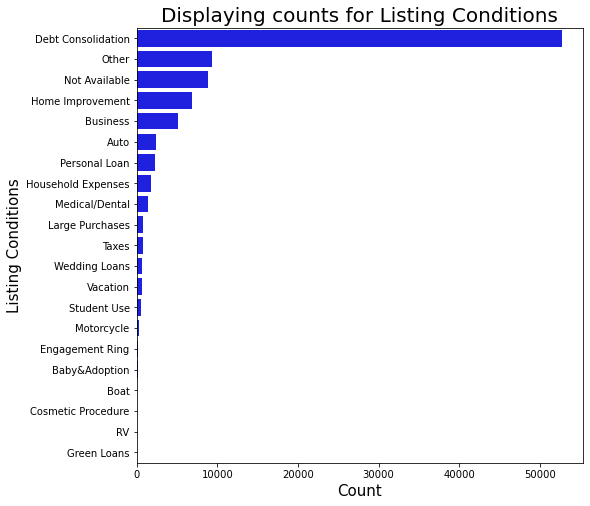

```python
# countplot
plt.figure(figsize=[8, 8])
sb.countplot(y='ListingConditions',data = loan_data,color='blue', order = Conditions.index)
plt.xlabel('Count', fontsize = 15)
plt.ylabel('Listing Conditions', fontsize = 15)
plt.title('Displaying counts for Listing Conditions', fontsize = 20)
```

> We can observe that the Debt Consolidation has the highest count. This means that the majority borrowers from this dataset are likely to be individuals who borrow money to settle the existing debt may be due to the fact that these loans have a lower interest rate.

### Discuss the distribution(s) of your variable(s) of interest. Were there any unusual points? Did you need to perform any transformations?

> Debt to income ratio(DTI) had some unusual points, with the majority of the data points being between 0 and 1 but there were few data points that went up to 10. Research show that lenders prefer a debt-to-income ratio that is between 28% and 36%. So, it is very unlikely that DTI would be greater than 1, therefore values that above 1 were dropped as outliers.  
> I also performed transformation on Loan original amount variable and Stated monthly income.  
> I did logarithmic transformation on Loan original amount and stated monthly income. Loan original amount was highly right skewed before transformation but after doing transformation I observed that most of the data points are precisely widely spread across the axis.

### Of the features you investigated, were there any unusual distributions? Did you perform any operations on the data to tidy, adjust, or change the form of the data? If so, why did you do this?

> I dropped 17376 missing values (NaN), that makes about 15% of data. The reason is, these values were not significant to change the outcome of my analysis.  
> I also dropped about 730 duplicated rows because they would have distorted my analysis.  
> I partioned the bar plot for Occupation variable, splitting it into 4 plots. I did this so that the frequency of each category can be easly visible.  
> I also change the encoding of the Listing category from numerical to categorical because using numerical encoding on a categorical variable is not precisely appealing.  
> I did some transformation on Debt to income ratio variable, Loan original amount variable, and Stated monthly income.  
> These transformations include:  
> 1- Changing bins size to reduce noise in the graph and view data more precisely.  
> 2- Using log xscale to make interpretations from the graph easy.  
> 3- Using xticks on the x axis, so that labels are perfectly displayed.  
> 4- Using axis labels with font size that distinguishes the categories of the label from the axis label itself.

## Bivariate Exploration

To start off with, I want to look at the pairwise correlations present between features in the data.

```python
numeric_vars = ['Term','BorrowerAPR','BorrowerRate','LenderYield','LoanOriginalAmount','DebtToIncomeRatio','EmploymentStatusDuration','StatedMonthlyIncome','AverageCreditScore']
categoric_vars = ['LoanStatus', 'Occupation', 'EmploymentStatus', 'IsBorrowerHomeowner', 'IncomeVerifiable', 'ListingConditions']
```

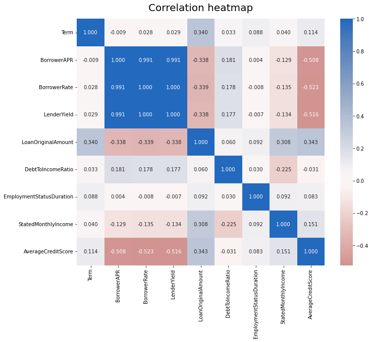

```python
# correlation plot
plt.figure(figsize = [11,9])
sb.heatmap(loan_data[numeric_vars].corr(), annot = True, fmt = '.3f',
           cmap = 'vlag_r', center = 0)
plt.title('Correlation heatmap', y = 1.02, fontsize = 20)
plt.show()
```

```
loan_data.shape= (95148, 15)
loan_data_samp.shape= (500, 15)
```

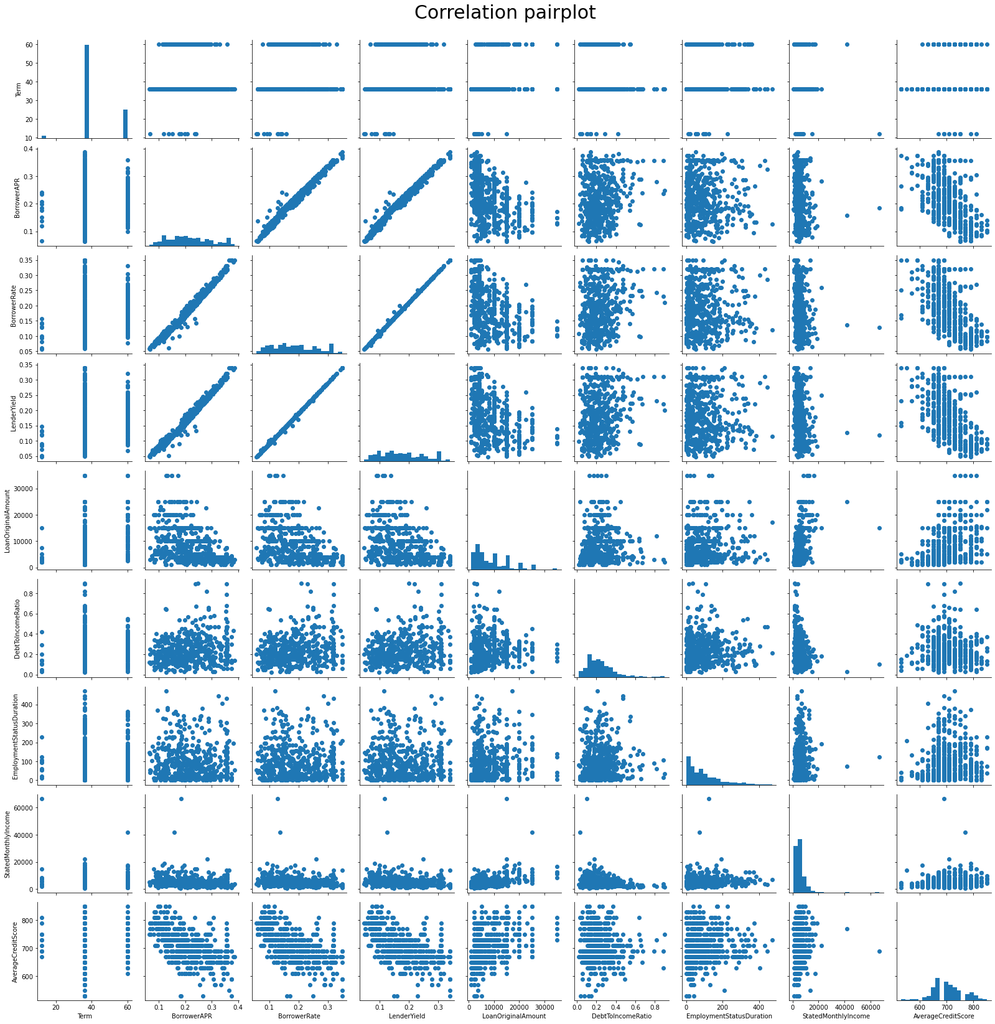

```python
# plot matrix: sample 500 loans so that plots are clearer and they render faster
print("loan_data.shape=",loan_data.shape)
loan_data_samp = loan_data.sample(n=500, replace = False)
print("loan_data_samp.shape=",loan_data_samp.shape)

g = sb.PairGrid(data = loan_data_samp, vars = numeric_vars)
g = g.map_diag(plt.hist, bins = 20);
g.map_offdiag(plt.scatter)
g.fig.suptitle('Correlation pairplot',y=1.02, fontsize = 30)
```

Lets look at the relationship between categorical variables

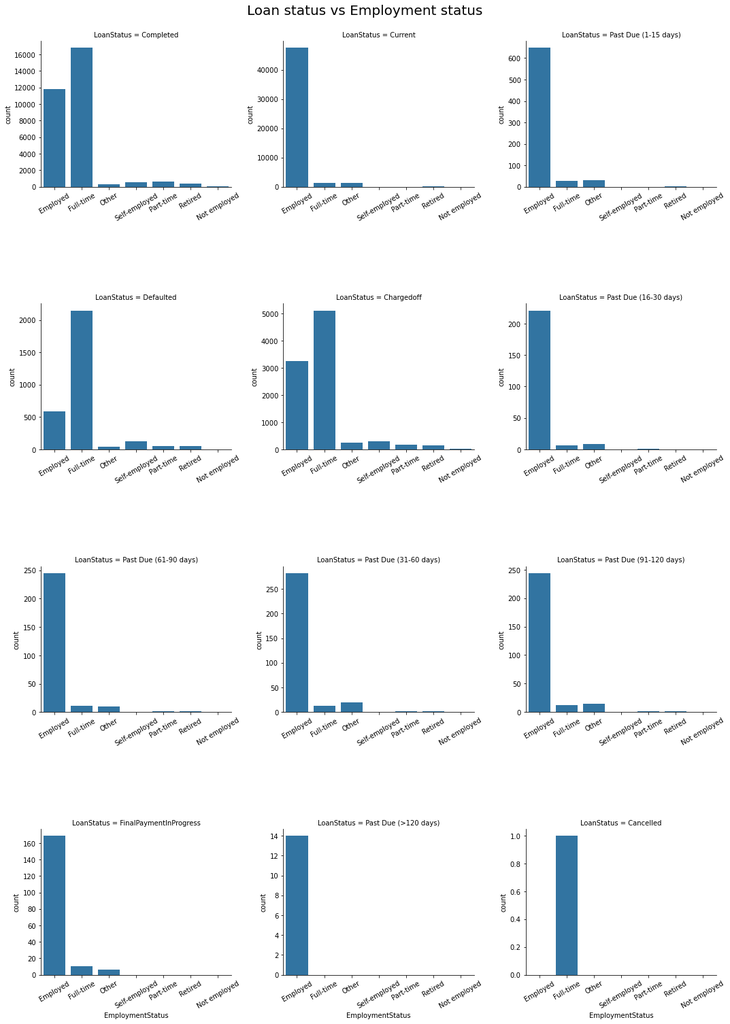

```python
ls=sb.FacetGrid(data=loan_data,col='LoanStatus',col_wrap=3,height=5,sharey=False,sharex=False)
ls.map(sb.countplot,'EmploymentStatus', order = Employment_Status.index)
ls.set_xticklabels(rotation=30)
plt.subplots_adjust(hspace = 0.8)
ls.fig.suptitle('Loan status vs Employment status',y=1.02, fontsize = 20);
```

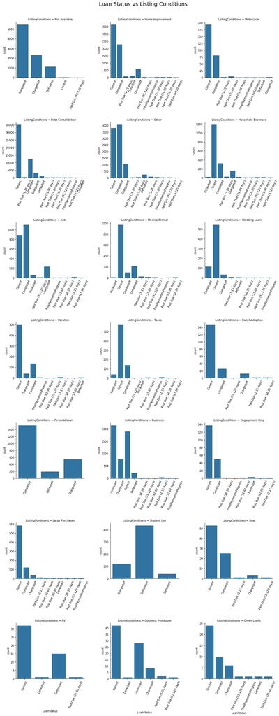

```python
ls=sb.FacetGrid(data=loan_data,col='ListingConditions',col_wrap=3,height=5,sharey=False,sharex=False)
ls.map(sb.countplot,'LoanStatus')
ls.set_xticklabels(rotation=65)
plt.subplots_adjust(hspace = 0.8)
ls.fig.suptitle('Loan Status vs Listing Conditions',y=1.02, fontsize = 20);
```

Lets look at the relationship between qualitative and quantitative variables.

[figure not shown]

```python
# plotting box plot.
loan_samp = loan_data.sample(n=5000, replace = False)
base_c=sb.color_palette()[9]
base_c2=sb.color_palette()[5]
g = sb.PairGrid(data = loan_samp, y_vars = ['BorrowerAPR', 'BorrowerRate'], x_vars = 'EmploymentStatus',height = 4.9,diag_sharey=False, aspect = 3)
g.map(sb.boxplot,color=base_c)
g.fig.suptitle('Employment status vs Borrower APR')
plt.title('Employment status vs Borrower rate')
plt.subplots_adjust(hspace = 0.2)
plt.show()
# plotting countplot.
```

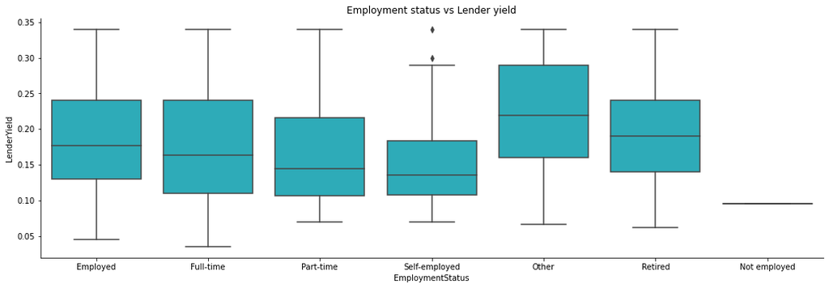

```python
g = sb.PairGrid(data = loan_samp, y_vars = ['LenderYield'], x_vars = 'EmploymentStatus',height = 4.9,diag_sharey=False, aspect = 3)
g.map(sb.boxplot,color=base_c)
plt.title('Employment status vs Lender yield');
```

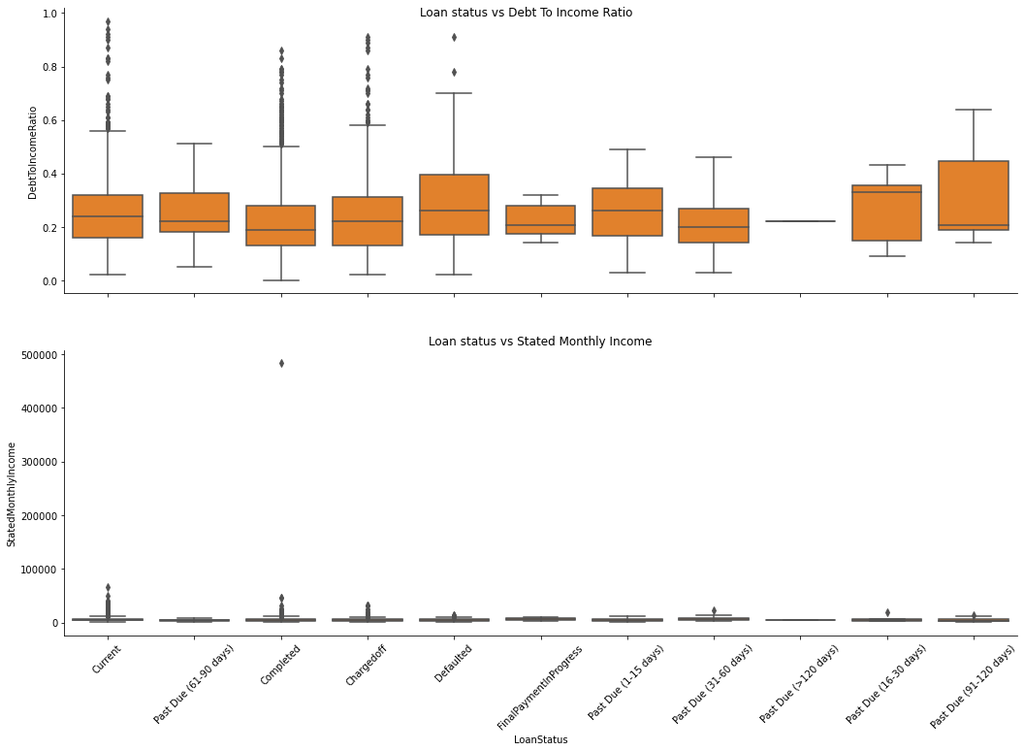

```python
# plotting box plot.
base_c=sb.color_palette()[1]
g = sb.PairGrid(data = loan_samp, y_vars = ['DebtToIncomeRatio', 'StatedMonthlyIncome'], x_vars = 'LoanStatus',height = 4.9,diag_sharey=False, aspect = 3)
g.map(sb.boxplot,color=base_c)
g.fig.suptitle('Loan status vs Debt To Income Ratio')
plt.title('Loan status vs Stated Monthly Income')
plt.subplots_adjust(hspace = 0.2)
plt.xticks(rotation=45)
plt.show()
```

```python
# log. transform on Stated Monthly Income
def log_trans(z,inverse=False):

    if not inverse:

        return np.log10(z)
    else:
        return z**3

loan_data['log_income'] = loan_data['StatedMonthlyIncome'].apply(log_trans)
```

```python
# cube-root transform on DTI
def cuberoot_trans(x, inverse = False):
    """ quick function for computing cube root and cube operations """
    if not inverse:
        return x ** (1/3)
    else:
        return x ** 3

loan_data['cr_DTI'] = loan_data['DebtToIncomeRatio'].apply(cuberoot_trans)
```

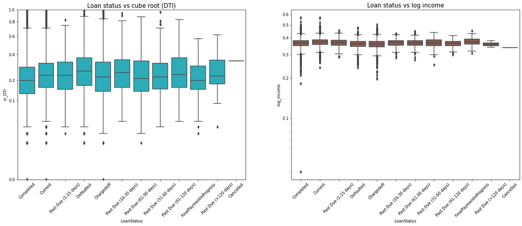

```python
# plotting box plot.
plt.figure(figsize=(23,8))
plt.subplot(1,2,1)
base_c=sb.color_palette()[9]
base_c2=sb.color_palette()[5]
sb.boxplot(data=loan_data,x='LoanStatus',y='cr_DTI',color=base_c)
crDTI_ticks = [0.0, 0.1, 0.2, 0.4, 0.6, 0.8, 1.0]
plt.yticks(cuberoot_trans(np.array(crDTI_ticks)), crDTI_ticks)
plt.ylim([cuberoot_trans(0.0), cuberoot_trans(1.0)])
plt.title('Loan status vs cube root (DTI)', fontsize = 15)
plt.xticks(rotation=45);

plt.subplot(1,2,2)
sb.boxplot(data=loan_data,x='LoanStatus',y='log_income',color=base_c2)
plt.yscale('log')
plt.yticks([0.1e1, 0.2e1, 0.3e1, 0.4e1, 0.5e1, 0.6e1], [0.1, 0.2, 0.3, 0.4, 0.5, 0.6])
plt.title('Loan status vs log income', fontsize = 15)
plt.xticks(rotation=45);
```

> - For the loan status vs cube root(DTI), there is not much change on the distribution of the box plots.
> - After taking the cubic root of DTI(debt to income ratio), we observe that 'defaulted' and 'cancelled' loan status have higher median scores of DTI than other loan status. This is likely because banks are reluctant to issues loan to borrowers with high DTI.
> - For loan status vs log income, we can observe that distribution of the box plots is better. I observe that the distribution for the log income accross the loan status categories now follows a normal distribution.

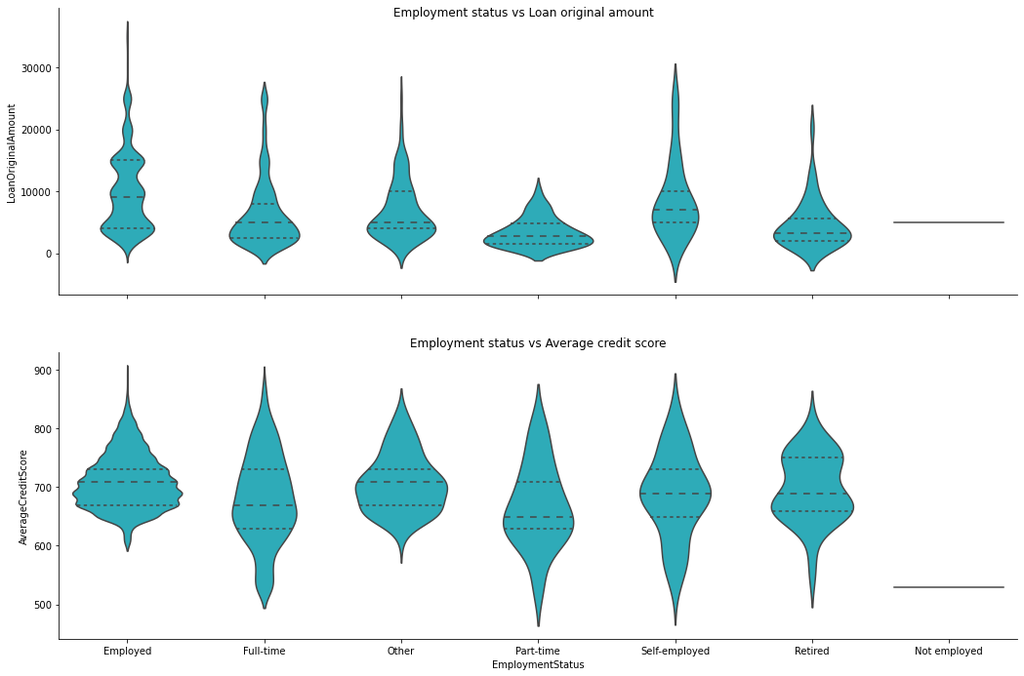

```python
# plotting violin plot.
g = sb.PairGrid(data = loan_samp, y_vars = ['LoanOriginalAmount', 'AverageCreditScore'], x_vars = 'EmploymentStatus',height = 4.9,diag_sharey=False, aspect = 3)
g.map(sb.violinplot,color=base_c, inner='quartile')
g.fig.suptitle('Employment status vs Loan original amount')
plt.title('Employment status vs Average credit score')
plt.subplots_adjust(hspace = 0.2)
plt.show()
```

### Talk about some of the relationships you observed in this part of the investigation. How did the feature(s) of interest vary with other features in the dataset?

> I observed that borrower APR and borrower rate are highly correlated. I also observed that borrowers that have employed employment status have higher loan original amount compared to other employment status categories.

## Multivariate Exploration

The aim of this section if to carry on forward issues that were not answered by bivariate analysis.

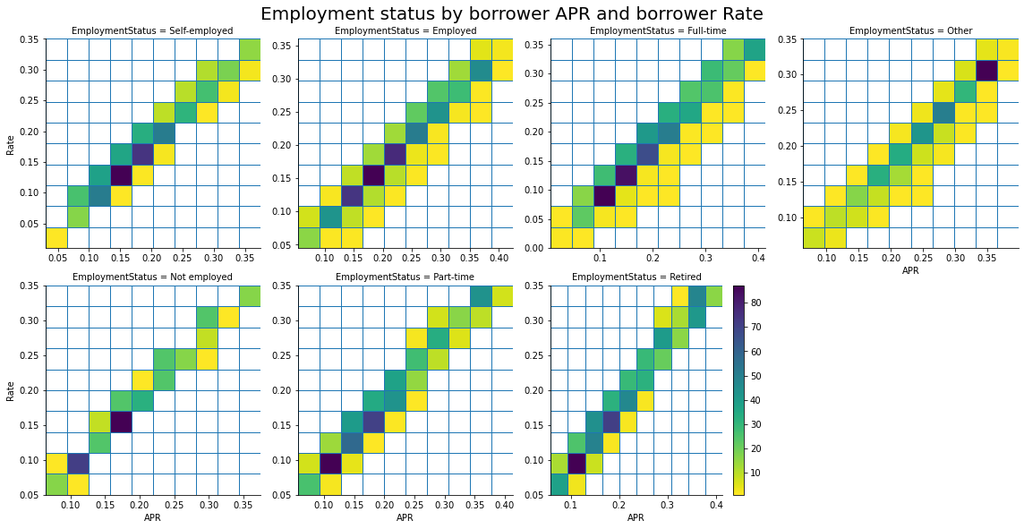

```python
# Plotting heatmap using seavorn's facetgrid
g = sb.FacetGrid(data = loan_data, col = 'EmploymentStatus', col_wrap = 4, height = 4,sharex=False,sharey=False)
g.map(plt.hist2d, 'BorrowerAPR', 'BorrowerRate', cmap = 'viridis_r', cmin = 0.5)
g.set_xlabels('APR')
g.set_ylabels('Rate')
g.fig.suptitle('Employment status by borrower APR and borrower Rate',y=1.02, fontsize = 20)
plt.colorbar()
plt.show()
```

> From above histogram 2d I have made several observations:  
> 1- Out of all employment status, 'other' status is the only ones with minimum count of APR and rate greater than 0.2.  
> 2- Rest of the employment status have a 'cloud' of points below 0.2 for both APR and Rate.  
> 3- If borrower APR and rate are less than loan than 0.2, employment status is more likely to be anything except 'other'.

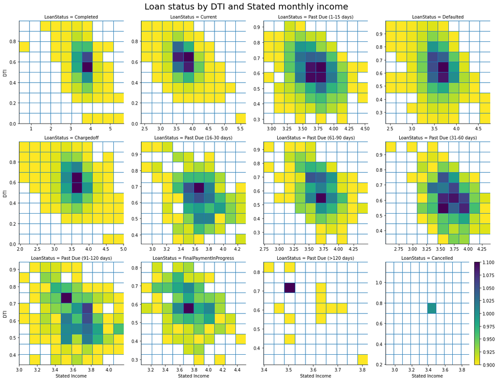

```python
# Plotting heatmap using seavorn's facetgrid
loan_data = loan_data[loan_data['log_income']>0]
g = sb.FacetGrid(data = loan_data, col = 'LoanStatus', col_wrap = 4, height = 4,sharex=False,sharey=False)
g.map(plt.hist2d, 'log_income', 'cr_DTI', cmap = 'viridis_r', cmin = 0.5)
g.set_xlabels('Stated Income')
g.set_ylabels('DTI')
g.fig.suptitle('Loan status by DTI and Stated monthly income',y=1.02, fontsize = 20)
plt.colorbar()
plt.show()
```

> From the 2d histogram, we can observe that loan status have high concentration data points at the middle of the quadrants except for 'Past due (>120days)' status. This generally means that DTI and stated monthly income have a weak association even though we applied some transformations.

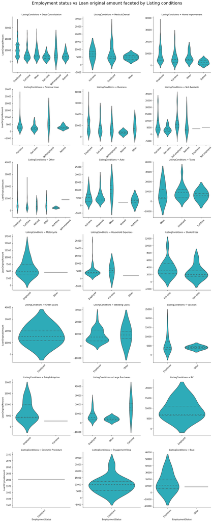

```python
# plotting box plot.
g = sb.FacetGrid(data = loan_samp, col='ListingConditions', col_wrap=3, height = 4.9, sharex=False,sharey=False)
g.map(sb.violinplot, 'EmploymentStatus', 'LoanOriginalAmount', color=base_c, inner='quartile')
g.set_xticklabels(rotation=45)
g.fig.suptitle('Employment status vs Loan original amount faceted by Listing conditions', y =1.02, fontsize = 20)
plt.subplots_adjust(hspace = 0.3)
plt.show()
```

> From the faceted violin plots, I observed that 'employed' employment status received higher loan original amount compared to other employment status categories for the majority listing conditions except of the following 'student use', 'personal loans', 'taxes' and 'not available'. This also means that borrowers with a 'employed' employment status are likely to list any of the listing conditions except for the ones previously noted.

### Were there any interesting or surprising interactions between features?

> I tried to further investigate the association of stated monthly income and DTI with another categorical variable like loan status but nothing surprising was observed.